# CalibrationDisplay

**classsklearn.calibration.CalibrationDisplay(*prob_true*, *prob_pred*, *y_prob*, *, *estimator_name=None*, *pos_label=None*)[[source]](https://github.com/scikit-learn/scikit-learn/blob/cc50648cc/sklearn/calibration.py#L1343)**

Calibration curve (also known as reliability diagram) visualization.

It is recommended to use `from_estimator` or `from_predictions` to create a `CalibrationDisplay`. All parameters are stored as attributes.

Read more about calibration in the User Guide and more about the scikit-learn visualization API in [Visualizations](https://scikit-learn.org/1.9/visualizations.html#visualizations).

For an example on how to use the visualization, see Probability Calibration curves.

Added in version 1.0.

**Parameters:**

**prob_true**ndarray of shape (n_bins,)**

The proportion of samples whose class is the positive class (fraction of positives), in each bin.

**prob_pred**ndarray of shape (n_bins,)**

The mean predicted probability in each bin.

**y_prob**ndarray of shape (n_samples,)**

Probability estimates for the positive class, for each sample.

**estimator_name**str, default=None**

Name of estimator. If None, the estimator name is not shown.

**pos_label**int, float, bool or str, default=None**

The positive class when calibration curve computed. If not `None`, this value is displayed in the x- and y-axes labels.

Added in version 1.1.

**Attributes:**

**line_**matplotlib Artist**

Calibration curve.

**ax_**matplotlib Axes**

Axes with calibration curve.

**figure_**matplotlib Figure**

Figure containing the curve.

See also

**`calibration_curve`**

Compute true and predicted probabilities for a calibration curve.

**`CalibrationDisplay.from_predictions`**

Plot calibration curve using true and predicted labels.

**`CalibrationDisplay.from_estimator`**

Plot calibration curve using an estimator and data.

#### Examples

```
>>> from sklearn.datasets import make_classification
>>> from sklearn.model_selection import train_test_split
>>> from sklearn.linear_model import LogisticRegression
>>> from sklearn.calibration import calibration_curve, CalibrationDisplay
>>> X, y = make_classification(random_state=0)
>>> X_train, X_test, y_train, y_test = train_test_split(
...     X, y, random_state=0)
>>> clf = LogisticRegression(random_state=0)
>>> clf.fit(X_train, y_train)
LogisticRegression(random_state=0)
>>> y_prob = clf.predict_proba(X_test)[:, 1]
>>> prob_true, prob_pred = calibration_curve(y_test, y_prob, n_bins=10)
>>> disp = CalibrationDisplay(prob_true, prob_pred, y_prob)
>>> disp.plot()
<...>
```

**classmethodfrom_estimator(*estimator*, *X*, *y*, *, *n_bins=5*, *strategy='uniform'*, *pos_label=None*, *name=None*, *ax=None*, *ref_line=True*, **kwargs)[[source]](https://github.com/scikit-learn/scikit-learn/blob/cc50648cc/sklearn/calibration.py#L1482)**

Plot calibration curve using a binary classifier and data.

A calibration curve, also known as a reliability diagram, uses inputs from a binary classifier and plots the average predicted probability for each bin against the fraction of positive classes, on the y-axis.

Extra keyword arguments will be passed to [`matplotlib.pyplot.plot`](https://matplotlib.org/stable/api/_as_gen/matplotlib.pyplot.plot.html#matplotlib.pyplot.plot).

Read more about calibration in the User Guide and more about the scikit-learn visualization API in [Visualizations](https://scikit-learn.org/1.9/visualizations.html#visualizations).

Added in version 1.0.

**Parameters:**

**estimator**estimator instance**

Fitted classifier or a fitted `Pipeline` in which the last estimator is a classifier. The classifier must have a predict_proba method.

**X**{array-like, sparse matrix} of shape (n_samples, n_features)**

Input values.

**y**array-like of shape (n_samples,)**

Binary target values.

**n_bins**int, default=5**

Number of bins to discretize the [0, 1] interval into when calculating the calibration curve. A bigger number requires more data.

**strategy**{‘uniform’, ‘quantile’}, default=’uniform’**

Strategy used to define the widths of the bins.

- `'uniform'`: The bins have identical widths.
- `'quantile'`: The bins have the same number of samples and depend on predicted probabilities.

**pos_label**int, float, bool or str, default=None**

The positive class when computing the calibration curve. By default, `estimators.classes_[1]` is considered as the positive class.

Added in version 1.1.

**name**str, default=None**

Name for labeling curve. If `None`, the name of the estimator is used.

**ax**matplotlib axes, default=None**

Axes object to plot on. If `None`, a new figure and axes is created.

**ref_line**bool, default=True**

If `True`, plots a reference line representing a perfectly calibrated classifier.

**kwargsdict**

Keyword arguments to be passed to [`matplotlib.pyplot.plot`](https://matplotlib.org/stable/api/_as_gen/matplotlib.pyplot.plot.html#matplotlib.pyplot.plot).

**Returns:**

**display**`CalibrationDisplay`.**

Object that stores computed values.

See also

**`CalibrationDisplay.from_predictions`**

Plot calibration curve using true and predicted labels.

#### Examples

```
>>> import matplotlib.pyplot as plt
>>> from sklearn.datasets import make_classification
>>> from sklearn.model_selection import train_test_split
>>> from sklearn.linear_model import LogisticRegression
>>> from sklearn.calibration import CalibrationDisplay
>>> X, y = make_classification(random_state=0)
>>> X_train, X_test, y_train, y_test = train_test_split(
...     X, y, random_state=0)
>>> clf = LogisticRegression(random_state=0)
>>> clf.fit(X_train, y_train)
LogisticRegression(random_state=0)
>>> disp = CalibrationDisplay.from_estimator(clf, X_test, y_test)
>>> plt.show()
```

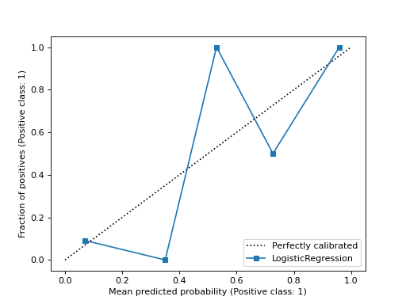

**classmethodfrom_predictions(*y_true*, *y_prob*, *, *n_bins=5*, *strategy='uniform'*, *pos_label=None*, *name=None*, *ax=None*, *ref_line=True*, **kwargs)[[source]](https://github.com/scikit-learn/scikit-learn/blob/cc50648cc/sklearn/calibration.py#L1606)**

Plot calibration curve using true labels and predicted probabilities.

Calibration curve, also known as reliability diagram, uses inputs from a binary classifier and plots the average predicted probability for each bin against the fraction of positive classes, on the y-axis.

Extra keyword arguments will be passed to [`matplotlib.pyplot.plot`](https://matplotlib.org/stable/api/_as_gen/matplotlib.pyplot.plot.html#matplotlib.pyplot.plot).

Read more about calibration in the User Guide and more about the scikit-learn visualization API in [Visualizations](https://scikit-learn.org/1.9/visualizations.html#visualizations).

Added in version 1.0.

**Parameters:**

**y_true**array-like of shape (n_samples,)**

True labels.

**y_prob**array-like of shape (n_samples,)**

The predicted probabilities of the positive class.

**n_bins**int, default=5**

Number of bins to discretize the [0, 1] interval into when calculating the calibration curve. A bigger number requires more data.

**strategy**{‘uniform’, ‘quantile’}, default=’uniform’**

Strategy used to define the widths of the bins.

- `'uniform'`: The bins have identical widths.
- `'quantile'`: The bins have the same number of samples and depend on predicted probabilities.

**pos_label**int, float, bool or str, default=None**

The positive class when computing the calibration curve. When `pos_label=None`, if `y_true` is in {-1, 1} or {0, 1}, `pos_label` is set to 1, otherwise an error will be raised.

Added in version 1.1.

**name**str, default=None**

Name for labeling curve.

**ax**matplotlib axes, default=None**

Axes object to plot on. If `None`, a new figure and axes is created.

**ref_line**bool, default=True**

If `True`, plots a reference line representing a perfectly calibrated classifier.

**kwargsdict**

Keyword arguments to be passed to [`matplotlib.pyplot.plot`](https://matplotlib.org/stable/api/_as_gen/matplotlib.pyplot.plot.html#matplotlib.pyplot.plot).

**Returns:**

**display**`CalibrationDisplay`.**

Object that stores computed values.

See also

**`CalibrationDisplay.from_estimator`**

Plot calibration curve using an estimator and data.

#### Examples

```
>>> import matplotlib.pyplot as plt
>>> from sklearn.datasets import make_classification
>>> from sklearn.model_selection import train_test_split
>>> from sklearn.linear_model import LogisticRegression
>>> from sklearn.calibration import CalibrationDisplay
>>> X, y = make_classification(random_state=0)
>>> X_train, X_test, y_train, y_test = train_test_split(
...     X, y, random_state=0)
>>> clf = LogisticRegression(random_state=0)
>>> clf.fit(X_train, y_train)
LogisticRegression(random_state=0)
>>> y_prob = clf.predict_proba(X_test)[:, 1]
>>> disp = CalibrationDisplay.from_predictions(y_test, y_prob)
>>> plt.show()
```

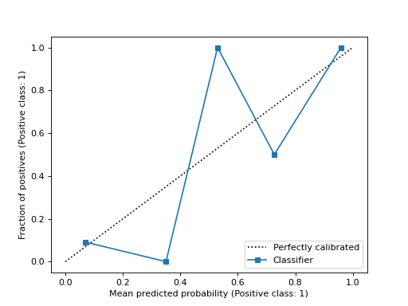

**plot(*, *ax=None*, *name=None*, *ref_line=True*, **kwargs)[[source]](https://github.com/scikit-learn/scikit-learn/blob/cc50648cc/sklearn/calibration.py#L1428)**

Plot visualization.

Extra keyword arguments will be passed to [`matplotlib.pyplot.plot`](https://matplotlib.org/stable/api/_as_gen/matplotlib.pyplot.plot.html#matplotlib.pyplot.plot).

**Parameters:**

**ax**Matplotlib Axes, default=None**

Axes object to plot on. If `None`, a new figure and axes is created.

**name**str, default=None**

Name for labeling curve. If `None`, use `estimator_name` if not `None`, otherwise no labeling is shown.

**ref_line**bool, default=True**

If `True`, plots a reference line representing a perfectly calibrated classifier.

**kwargsdict**

Keyword arguments to be passed to [`matplotlib.pyplot.plot`](https://matplotlib.org/stable/api/_as_gen/matplotlib.pyplot.plot.html#matplotlib.pyplot.plot).

**Returns:**

**display**`CalibrationDisplay`**

Object that stores computed values.

## Gallery examples

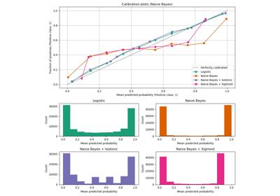

Probability Calibration curves

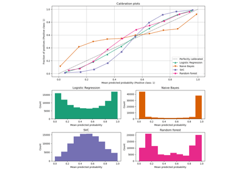

Comparison of Calibration of Classifiers

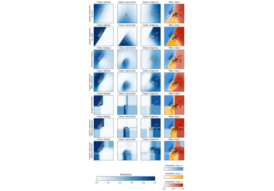

Plot classification probability

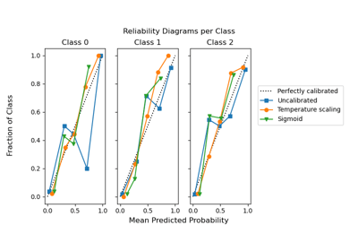

Release Highlights for scikit-learn 1.8

© 2007–2026 The scikit-learn developers  
Licensed under the 3-clause BSD License.  
https://scikit-learn.org/1.9/modules/generated/sklearn.calibration.CalibrationDisplay.html